# Un estudio cuantitativo preliminar sobre cambios de datación en obras de arte

Luciano Borgoglio

2023-10-23

## Introducción

Este cuaderno desarolla un análisis de los conjuntos de datos bajo el título [*Quantifying Art Narratives*](https://github.com/rfordatascience/tidytuesday/blob/master/data/2023/2023-01-17/readme.md) en *Tidy Tuesday*. Según su documentación:

> “This dataset contains data that was used for Holland Stam’s thesis work, titled Quantifying art historical narratives. The data was collected to assess the demographic representation of artists through editions of Janson’s *History of Art* and Gardner’s *Art Through the Ages*, two of the most popular art history textbooks used in the American education system. In this package specifically, both artist-level and work-level data was collected along with variables regarding the artists’ demographics and numeric metrics for describing how much space they or their work took up in each edition of each textbook.”

El paquete de *R* [*arthistory*](https://cloud.r-project.org/web/packages/arthistory/index.html) ofrece una manera sencilla de acceder a los conjuntos de datos y una documentación detallada de cada uno. Importamos librerías, descargamos los conjuntos de datos, construimos una base de datos a su alrededor y la describimos:

```r
# Remove all objects from the environment and clean memory
rm(list = ls())
gc()
```

```
##          used (Mb) gc trigger (Mb) max used (Mb)
## Ncells 520681 27.9    1157467 61.9   660385 35.3
## Vcells 951361  7.3    8388608 64.0  1770967 13.6
```

```r
# List of libraries to load
libraries <- c("arthistory", "ggplot2", "dplyr", "DBI", "RSQLite", "purrr", "reactable")

# Install (if necessary) and load libraries
for (library_name in libraries) {
  if (!requireNamespace(library_name, quietly = TRUE)) {
    install.packages(library_name, dependencies = TRUE)
  }
  library(library_name, character.only = TRUE)
}

# Load datasets to environment
artists <- artists
worksgardner <- worksgardner
worksjanson <- worksjanson

# Build database connection
con <- dbConnect(RSQLite::SQLite(), dbname = ":memory:")

# Add data frames to the SQLite database
dbWriteTable(con, "artists", as.data.frame(artists))
dbWriteTable(con, "worksgardner", as.data.frame(worksgardner))
dbWriteTable(con, "worksjanson", as.data.frame(worksjanson))
```

```r
glimpse(artists)
```

```
## Rows: 3,162
## Columns: 14
## $ artist_name                <chr> "Aaron Douglas", "Aaron Douglas", "Aaron Do…
## $ edition_number             <dbl> 9, 10, 11, 12, 13, 14, 15, 16, 14, 15, 16, …
## $ year                       <dbl> 1991, 1996, 2001, 2005, 2009, 2013, 2016, 2…
## $ artist_nationality         <chr> "American", "American", "American", "Americ…
## $ artist_nationality_other   <chr> "American", "American", "American", "Americ…
## $ artist_gender              <chr> "Male", "Male", "Male", "Male", "Male", "Ma…
## $ artist_race                <chr> "Black or African American", "Black or Afri…
## $ artist_ethnicity           <chr> "Not Hispanic or Latino origin", "Not Hispa…
## $ book                       <chr> "Gardner", "Gardner", "Gardner", "Gardner",…
## $ space_ratio_per_page_total <dbl> 0.3533658, 0.3739470, 0.3032593, 0.3770489,…
## $ artist_unique_id           <dbl> 2, 2, 2, 2, 2, 2, 2, 2, 4, 4, 4, 6, 6, 6, 6…
## $ moma_count_to_year         <dbl> 0, 0, 0, 0, 0, 0, 0, 0, 0, 0, 0, 0, 0, 0, 0…
## $ whitney_count_to_year      <dbl> 0, 0, 0, 0, 0, 0, 0, 0, 0, 0, 0, 0, 0, 0, 0…
## $ artist_race_nwi            <chr> "Non-White", "Non-White", "Non-White", "Non…
```

```r
glimpse(worksgardner)
```

```
## Rows: 2,325
## Columns: 24
## $ artist_name            <chr> "Aaron Douglas", "Aaron Douglas", "Aaron Dougla…
## $ edition_number         <dbl> 9, 10, 11, 12, 13, 14, 15, 16, 14, 15, 16, 5, 6…
## $ title_of_work          <chr> "Noah's Ark", "Noah's Ark", "Noah's Ark", "Noah…
## $ publication_year       <dbl> 1991, 1996, 2001, 2005, 2009, 2013, 2016, 2020,…
## $ page_number_of_image   <chr> "965", "1053", "1030", "990", "937", "867", "91…
## $ artist_unique_id       <dbl> 1, 1, 1, 1, 1, 1, 1, 1, 2, 2, 2, 3, 3, 3, 3, 3,…
## $ artist_nationality     <chr> "American", "American", "American", "American",…
## $ artist_gender          <chr> "Male", "Male", "Male", "Male", "Male", "Male",…
## $ artist_race            <chr> "Black or African American", "Black or African …
## $ artist_ethnicity       <chr> "Not Hispanic or Latinx", "Not Hispanic or Lati…
## $ height_of_work_in_book <dbl> 11.3, 12.1, 12.3, 12.3, 12.8, 12.8, 12.7, 7.9, …
## $ width_of_work_in_book  <dbl> 8.5, 8.9, 8.8, 8.8, 9.3, 9.3, 9.2, 19.0, 10.2, …
## $ height_of_text         <dbl> 14.5, 12.4, 10.8, 15.7, 15.0, 18.8, 21.2, 14.7,…
## $ width_of_text          <dbl> 8.4, 9.0, 9.0, 8.9, 9.3, 9.3, 9.2, 13.9, 9.3, 9…
## $ extra_text_height      <dbl> 0.0, 0.0, 0.0, 0.0, 0.0, 0.0, 0.0, 0.0, 9.2, 0.…
## $ extra_text_width       <dbl> 0.0, 0.0, 0.0, 0.0, 0.0, 0.0, 0.0, 0.0, 8.8, 0.…
## $ area_of_work_in_book   <dbl> 96.05, 107.69, 108.24, 108.24, 119.04, 119.04, …
## $ area_of_text           <dbl> 121.80, 111.60, 97.20, 139.73, 139.50, 174.84, …
## $ extra_text_area        <dbl> 0.00, 0.00, 0.00, 0.00, 0.00, 0.00, 0.00, 0.00,…
## $ total_area_text        <dbl> 121.80, 111.60, 97.20, 139.73, 139.50, 174.84, …
## $ total_space            <dbl> 217.85, 219.29, 205.44, 247.97, 258.54, 293.88,…
## $ page_area              <dbl> 616.500, 586.420, 677.440, 657.660, 648.930, 64…
## $ space_ratio_per_page   <dbl> 0.3533658, 0.3739470, 0.3032593, 0.3770489, 0.3…
## $ book                   <chr> "gardner", "gardner", "gardner", "gardner", "ga…
```

```r
glimpse(worksjanson)
```

```
## Rows: 1,634
## Columns: 25
## $ artist_name                      <chr> "A. R. Penck", "A. R. Penck", "Aaron …
## $ artist_unique_id                 <dbl> 1, 1, 2, 2, 2, 2, 3, 3, 4, 4, 5, 6, 6…
## $ artist_nationality               <chr> "German", "German", "American", "Amer…
## $ artist_gender                    <chr> "Male", "Male", "Male", "Male", "Male…
## $ artist_race                      <chr> "White", "White", "White", "White", "…
## $ artist_ethnicity                 <chr> "Not Hispanic or Latinx", "Not Hispan…
## $ title_of_work                    <chr> "The Demon of Curiosity", "The Demon …
## $ edition_number                   <dbl> 5, 6, 3, 4, 5, 6, 5, 6, 7, 8, 7, 7, 8…
## $ publication_year                 <dbl> 1995, 2001, 1986, 1991, 1995, 2001, 1…
## $ part_in_text                     <dbl> 4, 4, 4, 4, 4, 4, 4, 4, 4, 4, 4, 4, 4…
## $ chapter_title                    <chr> "Post-Modernism", "Post-Modernism", "…
## $ start_date                       <dbl> 1982, 1982, 1951, 1951, 1951, 1951, 1…
## $ end_date                         <dbl> 1982, 1982, 1951, 1951, 1951, 1951, 1…
## $ circa                            <chr> "0", "0", "0", "0", "0", "0", "0", "0…
## $ medium                           <chr> "Acrylic on canvas", "Acrylic on canv…
## $ height_of_work_in_book           <dbl> 8.5725, 8.5725, 11.1125, 11.1125, 10.…
## $ width_of_work_in_book            <dbl> 8.8900, 8.8900, 8.8900, 8.8900, 8.890…
## $ height_of_text                   <dbl> 12.0650, 10.7950, 3.1750, 3.1750, 3.1…
## $ width_of_text                    <dbl> 8.890, 8.890, 8.890, 8.890, 8.890, 8.…
## $ area_actual_work                 <chr> "78419.60123", "78419.60123", "0", "0…
## $ area_of_work_in_book             <dbl> 76.20952, 76.20952, 98.79013, 98.7901…
## $ area_of_text                     <dbl> 107.25785, 95.96755, 28.22575, 28.225…
## $ work_to_figure_ratio             <chr> "1029", "1029", "0", "0", "0", "0", "…
## $ work_in_text_in_color            <dbl> 1, 1, 0, 0, 0, 0, 1, 1, 1, 1, 1, 1, 1…
## $ location_as_catalogued_in_janson <chr> "Riverdell Collection, New York. Cour…
```

Entre las novedades ofrecidas por estos conjuntos de datos (que el autor construyó y explotó para su tesis de doctorado), se destaca la medición del espacio ocupado en cada edición de los citados ibros de *Jansen* y *Gardner*, canónicos en el campo disciplinar de la Historia del Arte, tanto en texto como en imagen, de un gran conjunto de obras.

Para elegir la pregunta a realizarle a la base de datos, quise explotar esa información y relacionarla con algo más que sea interesante desde el punto de vista de la disciplina y que no se vincule solamente a atributos demográficos de los artistas. La variable que consideré más rica a esos efectos es *circa*, presente solo en el conjunto de datos para el libro de Jansen; si una obra de arte tiene una datación (atribución de años de comienzo y finalización de la obra) calificada con “circa” implica que los años de comienzo (*start_date*) y finalización (*end_date*) del trabajo del cual la obra es producto no se consideran exactos sino tan sólo aproximados. Esta atribución, la datación, es la más importante después de la del artista que produjo la obra. De acuerdo con la documentación:

> “circa 1 if the date of the work was labeled with a circa (around) and 0 if the date of the work was not labeled with a circa”

Los motivos por los cuales una obra puede cambiar tal estado son múltiples, producto de la investigación en la disciplina, que a lo largo del tiempo puede ir ofreciendo nuevas pruebas cuestionen las dataciones ya establecidas. La atribución de *circa* a la datación implica que, con el conocimiento disponible en un momento determinado, *se considera* a los años como aproximados y no necesariamente que realmente lo sean. Es decir, puede darse, y se da el caso, de que los años atribuidos se tomen incorrectamente como exactos así como que se consideren incorrectamente como aproximados.

Observemos en previamente la cantidad total de obras de arte y de artistas diferentes presentes en el dataset:

```r
# SQL query to count unique values for title_of_work
query_unique_titles <- "SELECT COUNT(DISTINCT title_of_work) as unique_titles FROM worksjanson"

# Execute the query
unique_titles <- dbGetQuery(con, query_unique_titles)
print(unique_titles)
```

```
##   unique_titles
## 1           449
```

```r
# SQL query to count unique values for title_of_work
query_unique_artists <- "SELECT COUNT(DISTINCT artist_name) as unique_artists FROM worksjanson"

# Execute the query
unique_artists <- dbGetQuery(con, query_unique_artists)
print(unique_artists)
```

```
##   unique_artists
## 1            243
```

Realizaremos una búsqueda en el conjunto de datos para establecer la lista de obras de arte que cambia su status de *circa* (de *1* a *0* o de *0* a *1*) al menos una vez durante su existencia. Incluimos otras variables que son invariantes a lo largo de la existencia de la obra, relativas al artista.

```r
query_circa_changes <- "
SELECT artist_name, title_of_work, start_date, end_date, artist_nationality, artist_gender, artist_race, artist_ethnicity
FROM worksjanson AS w1
WHERE (w1.circa = 1 AND
       EXISTS (SELECT 1
               FROM worksjanson AS w2
               WHERE w2.artist_name = w1.artist_name
               AND w2.title_of_work = w1.title_of_work
               AND w2.circa = 0
               AND w2.publication_year > w1.publication_year))
   OR (w1.circa = 0 AND
       EXISTS (SELECT 1
               FROM worksjanson AS w3
               WHERE w3.artist_name = w1.artist_name
               AND w3.title_of_work = w1.title_of_work
               AND w3.circa = 1
               AND w3.publication_year > w1.publication_year))
GROUP BY artist_name, title_of_work
"

circa_changes <- dbGetQuery(con, query_circa_changes)

# Write the data frame to the database to create the table
dbWriteTable(con, "circa_changes", circa_changes, overwrite = TRUE)

# Show
circa_changes %>%
  reactable()
```

| artist_name | title_of_work | start_date | end_date | artist_nationality | artist_gender | artist_race | artist_ethnicity |
| --- | --- | --- | --- | --- | --- | --- | --- |
| Dante Gabriel Rossetti | Beata Beatrix | 1872 | 1872 | British | Male | White | Not Hispanic or Latinx |
| Edgar Degas | The Orchestra of the Paris Opéra | 1870 | 1870 | French | Male | White | Not Hispanic or Latinx |
| Eugène Delacroix | Odalisque | 1845 | 1850 | French | Male | White | Not Hispanic or Latinx |
| Francis Bacon | Head Surrounded by Sides of Beef | 1954 | 1954 | British | Male | White | Not Hispanic or Latinx |
| Gustave Moreau | The Apparition (Dance of Salomé) | 1876 | 1876 | French | Male | White | Not Hispanic or Latinx |
| Henry Fuseli | The Nightmare | 1785 | 1790 | Swiss | Male | White | Not Hispanic or Latinx |
| Honoré Daumier | Don Quixote Attacking the Windmills | 1866 | 1866 | French | Male | White | Not Hispanic or Latinx |
| Honoré Daumier | It's Safe to Release This One! | 1834 | 1834 | French | Male | White | Not Hispanic or Latinx |
| Honoré Daumier | The Third-Class Carriage | 1862 | 1862 | French | Male | White | Not Hispanic or Latinx |
| James Abbott McNeill Whistler | Nocturne in Black and Gold: The Falling Rocket | 1874 | 1874 | American | Male | White | Not Hispanic or Latinx |

[output cut: 5 more lines]

Tenemos entonces 15 obras de arte (de un total de 449) de 13 artistas diferentes (de un total de 243) que, en algún punto de sus vidas, cambiaron su status de *circa*. Vemos entonces que no es de lo más común este fenómeno. Los artistas son todos hombres blancos del Reino Unido, Francia, Suiza, Estados Unidos, Rusia e Italia. Todos los artistas tienen una sola obra en este subconjunto de datos excepto Honoré Daumier que tiene 3.

Veamos las trayectorias a lo largo de las distintas ediciones sucesivas del libro de Janson para cada una de las obras. Filtramos tanto por obra como por artista, ya que puede ocurrir (y ocurre en el conjunto de datos) que distintos artistas utilizan el mismo título para sus respectivas (diferentes) obras.

```r
filter_works <- function(title, artist) {
  worksjanson %>%
    filter(title_of_work == title, artist_name == artist) %>%
    select(artist_name, title_of_work, medium, publication_year, circa, start_date, end_date, area_of_text, artist_nationality, artist_gender, artist_race, artist_ethnicity, chapter_title, location_as_catalogued_in_janson)
}

# Use purrr to map the function to each title_of_work in circa_changes$title_of_work
trajectories <- map2(circa_changes$title_of_work, circa_changes$artist_name, filter_works)

# Loop through the list of tables and write each table to the database
for (i in seq_along(trajectories)) {
  table_name <- paste0("trajectory_", i)
  dbWriteTable(con, table_name, trajectories[[i]])
}

# Define the columns to show
columns_to_show <- c(
  "title_of_work",
  "artist_name",
  "publication_year",
  "start_date",
  "end_date",
  "circa",
  "location_as_catalogued_in_janson"
)

# Process each table in the list and create Reactable tables
walk(trajectories, function(table) {
  # Select only the desired columns
  selected_table <- select(table, all_of(columns_to_show))

  # Create a Reactable table
  rt <- reactable(selected_table)

  # Print the Reactable table
  print(rt)
})
```

[output not shown]

Vemos que existen casos en que además de *circa* cambia también *start_date* and *end_date* así como también existen casos en lo que cambia *circa* pero no las fechas. Un cambio a *circa = 1* califica la datación volviéndola aproximada pero no necesariamente cambia los años.

A lo largo de su vida en las sucesivas ediciones del libro de Janson, las obras empezaron con 0 y terminaron con 1 (se pasa a establecer la inexactitud de la datación) son:

- *Beata Beatrix* - Dante Gabriel Rossetti
- *Don Quixote Attacking the Windmills* - Honoré Daumier
- *The Third-Class Carriage* - Honoré Daumier

Empezaron con 1 y terminaron con 0 (se pasa a establecer la exactitud de la datación):

- *The Orchestra of the Paris Opéra* - Edgar Degas
- *Odalisque* - Eugène Delacroix
- *Head Surrounded by Sides of Beef* - Head Surrounded by Sides of Beef
- *Suprematist Composition: White on White* - Kazimir Malevich
- *The Sacred Grove* - Pierre Puvis de Chavannes

El resto de las obras tienen trayectorias más sinuosas, en la que cambiaron más de una vez de estado:

- *The Apparition (Dance of Salomé)* - Gustave Moreau
- *It’s Safe to Release This One!* - Honoré Daumier
- *Nocturne in Black and Gold: The Falling Rocket* - James Abbott McNeill Whistler
- *Le Metafisyx (Corps de Dame)* - Jean Dubuffet
- *The Nightmare* - Henry Fuseli
- *Offerings of Gratitude* - Paul Gauguin
- *The Conversion of St. Paul* - Taddeo Zuccari

Observemos gráficamente la evolución de las dataciones (año de comienzo y de finalización) así como del status de *circa*:

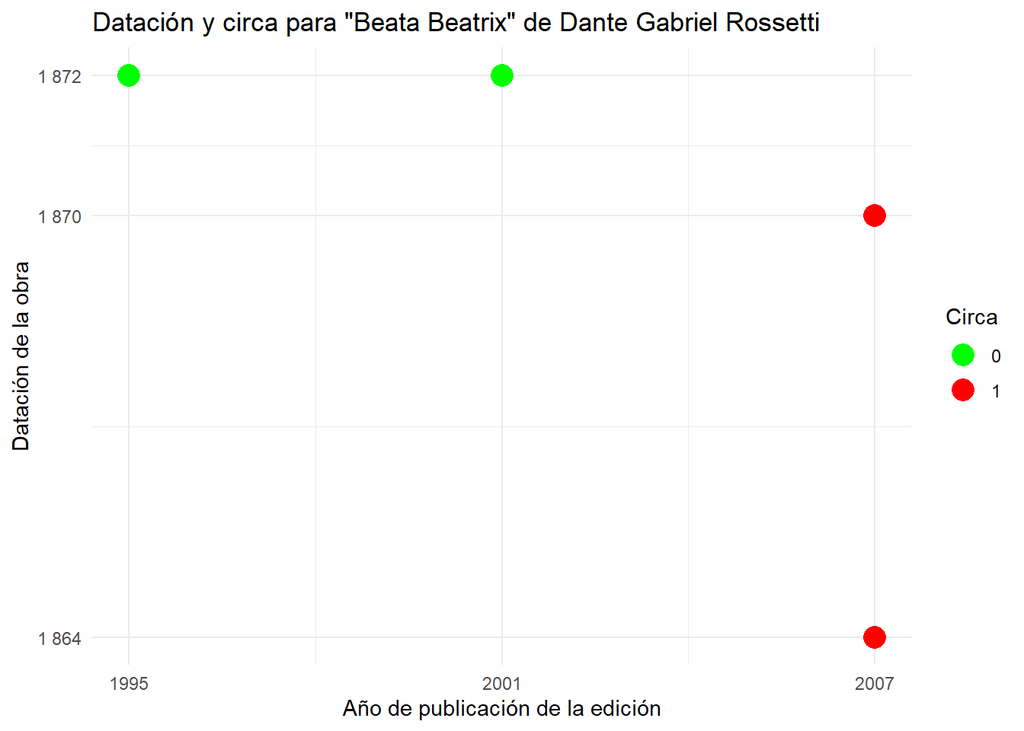

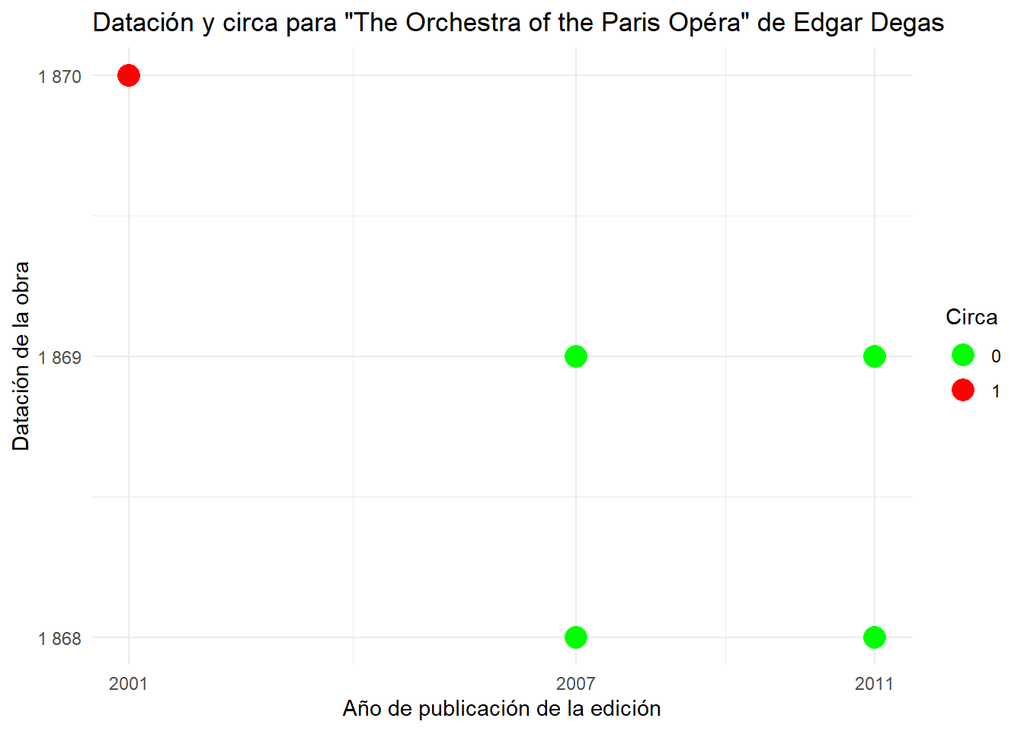

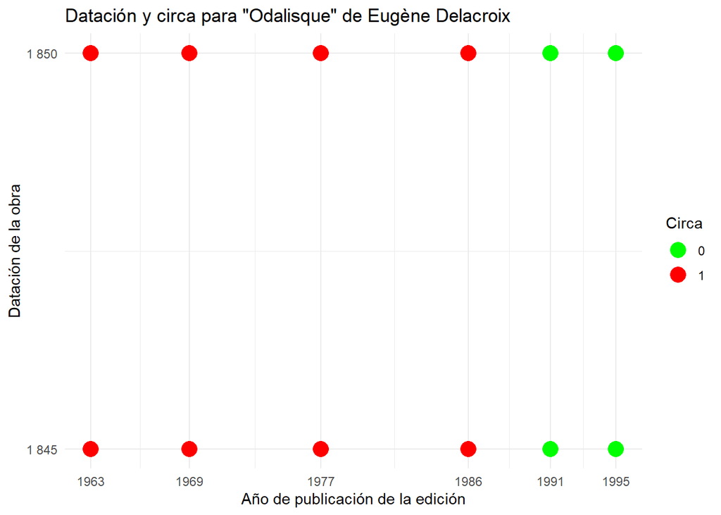

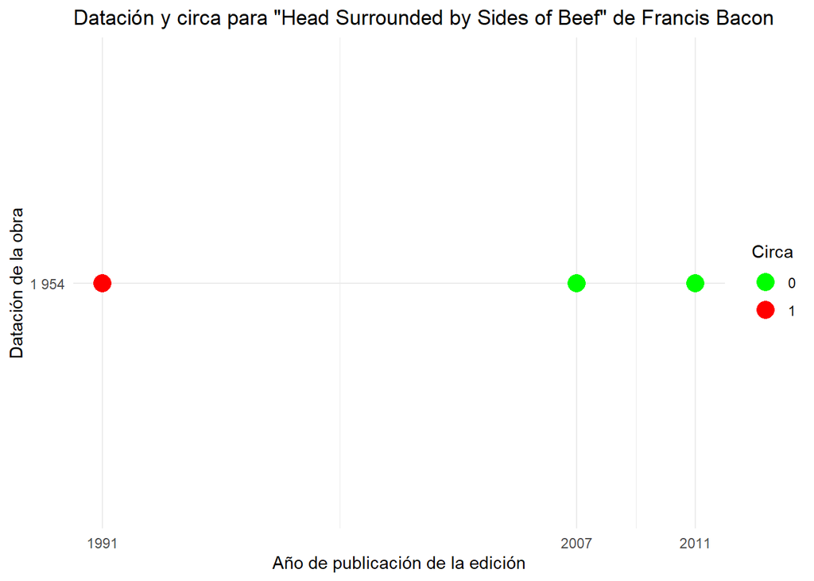

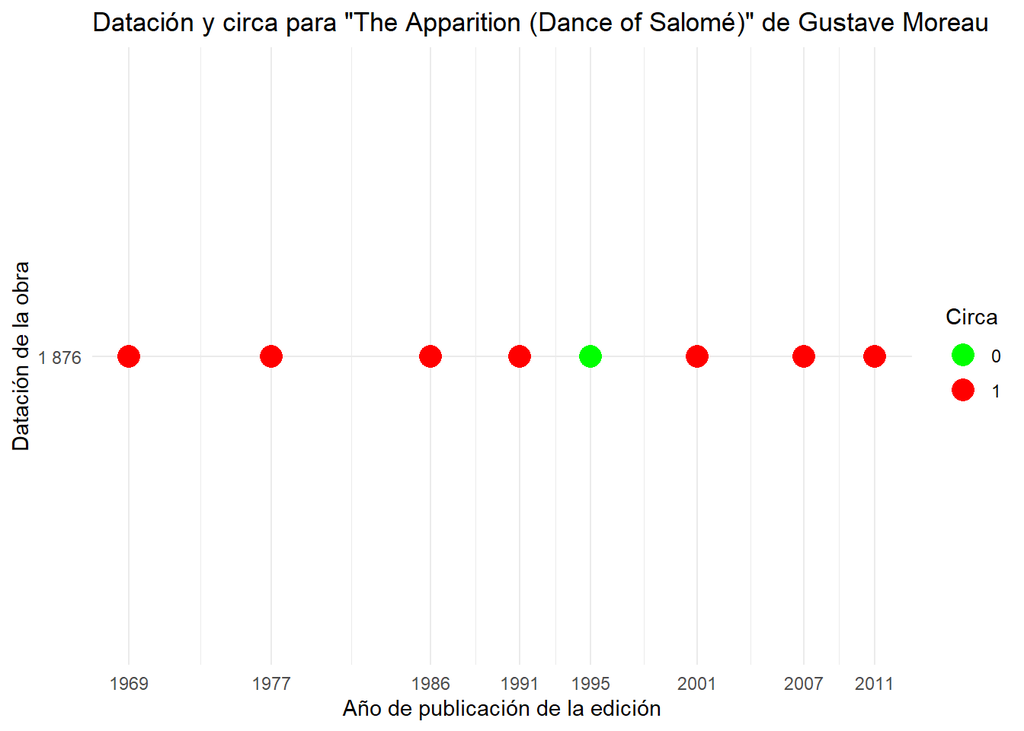

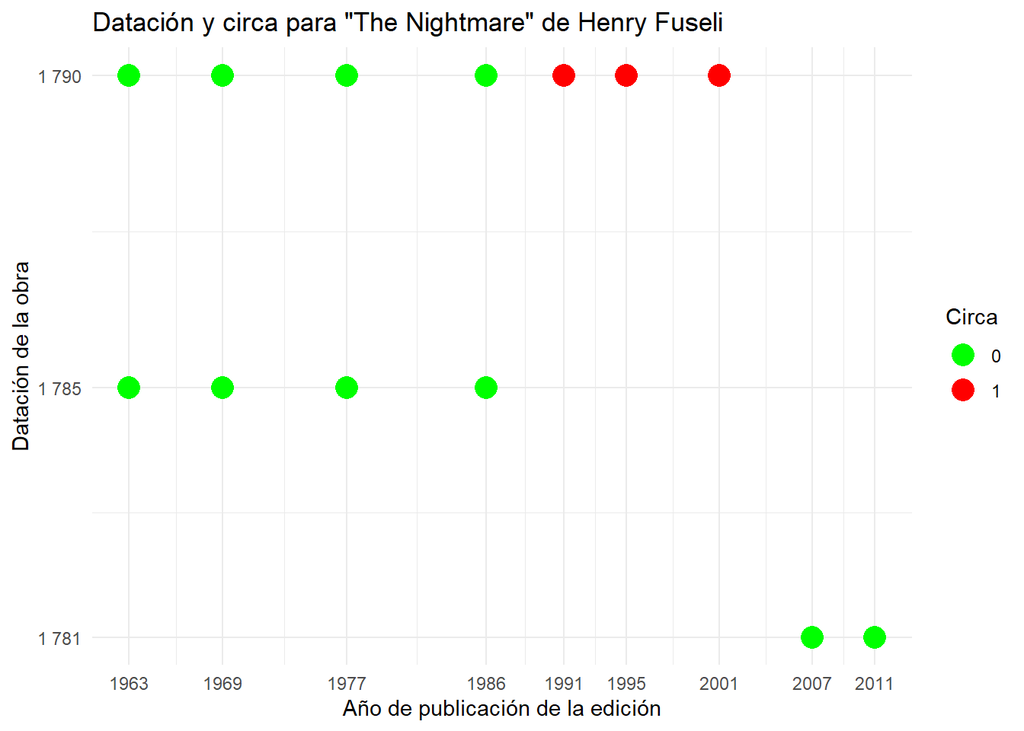

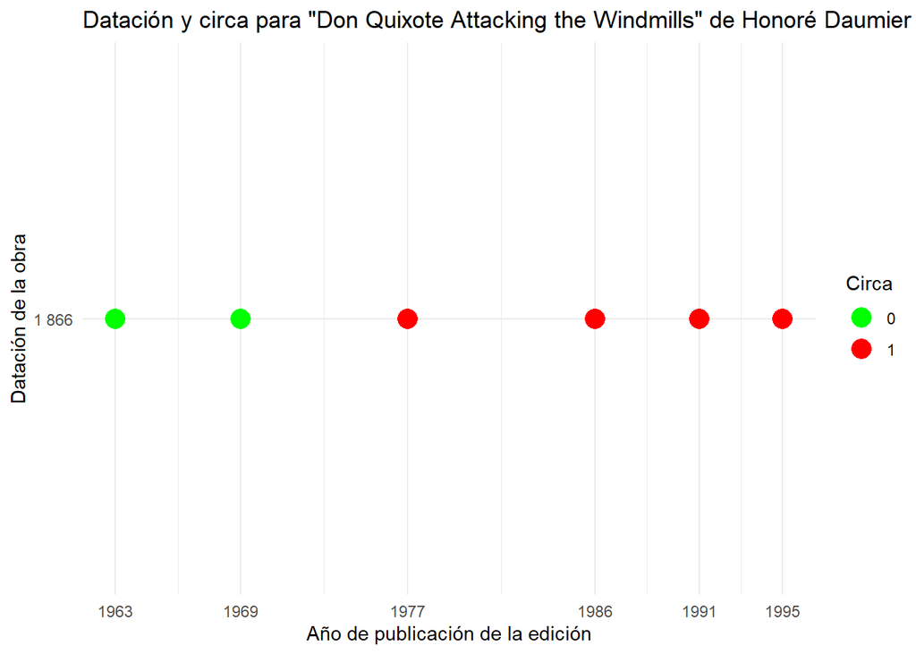

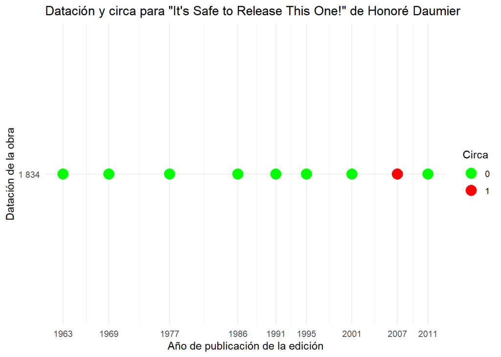

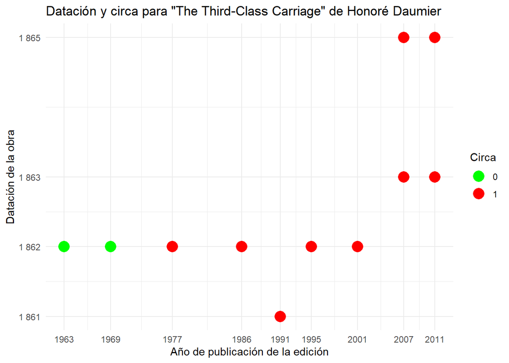

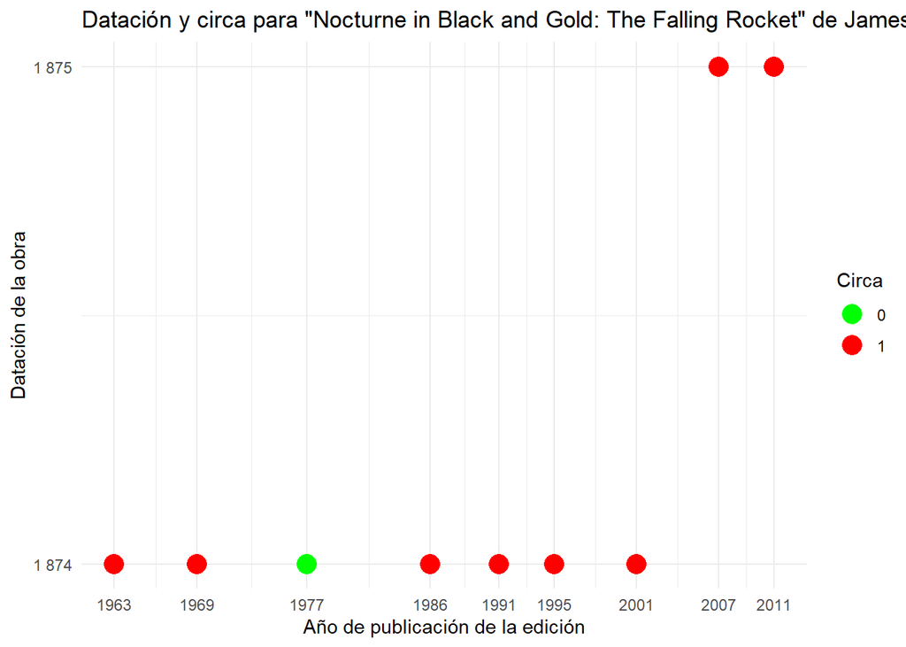

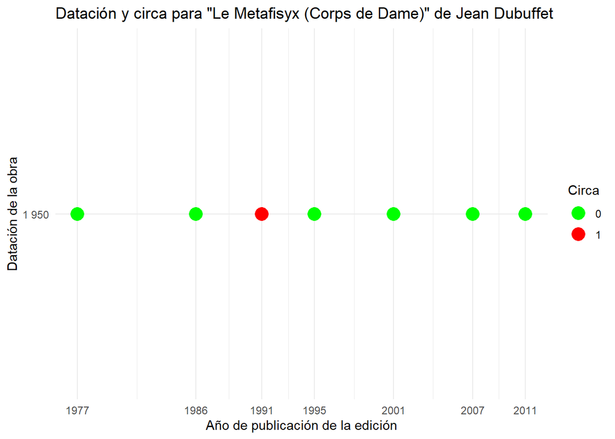

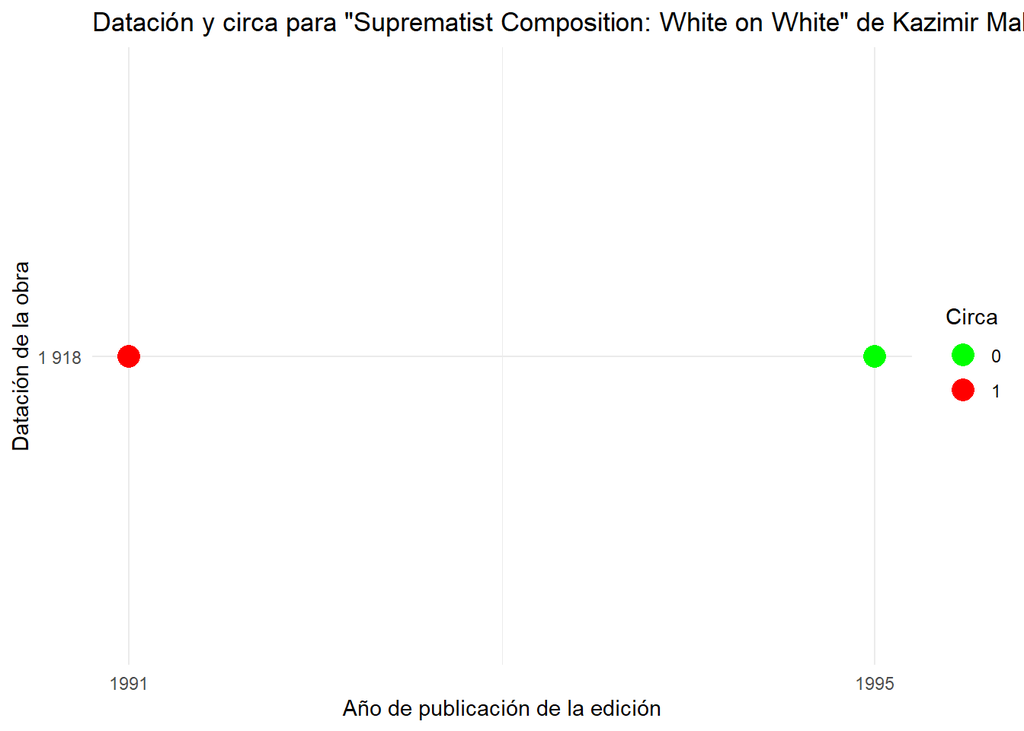

[3 more figures not shown]

```r
# Create a list of plots
plots_list <- map(trajectories, ~ {
  .x <- mutate(.x, start_date = as.integer(start_date), end_date = as.integer(end_date))
  title_of_work <- .x$title_of_work[1]
  artist_name <- .x$artist_name[1]
  unique_years <- sort(unique(c(.x$start_date, .x$end_date)))  # Get all unique years

  ggplot(.x, aes(x = publication_year)) +
    geom_point(aes(y = start_date, color = as.factor(circa)), size = 5) +  # Increase dot size
    geom_point(aes(y = end_date, color = as.factor(circa)), size = 5) +  # Increase dot size
    scale_color_manual(values = c("1" = "red", "0" = "green")) +
    labs(
      title = paste("Datación y circa para", shQuote(title_of_work), "de", artist_name),
      x = "Año de publicación de la edición",
      y = "Datación de la obra",
      color = "Circa"
    ) +
    scale_x_continuous(breaks = unique(.x$publication_year)) +  # Set unique publication years as breaks
    scale_y_continuous(breaks = unique_years, labels = scales::number_format(scale = 1)) +  # Add labels to the y-axis
    theme_minimal()  # Optional: Customize the theme as needed
})

# Print the list of plots
walk(plots_list, print)
```

Podemos ver cómo los intervalos correspondientes a las dataciones varían, cómo de intervalos se pasan a puntos y de puntos a intervalos, con o sin cambios de *circa*.

Como decíamos, los motivos por los cuales pueden ponerse en cuestión la datación son variados, veamos si podemos encontrar alguna regularidad de la relación entre el interés por la disciplina en las distintas obras (generando investigación que podrá cuestionar las dataciones), usando como *proxy* el espacio que ocupan en el libro de *Jansen*:

> *area_of_text*: The area in centimeter’s squared of the text of given work in a given edition of Janson’s History of Art

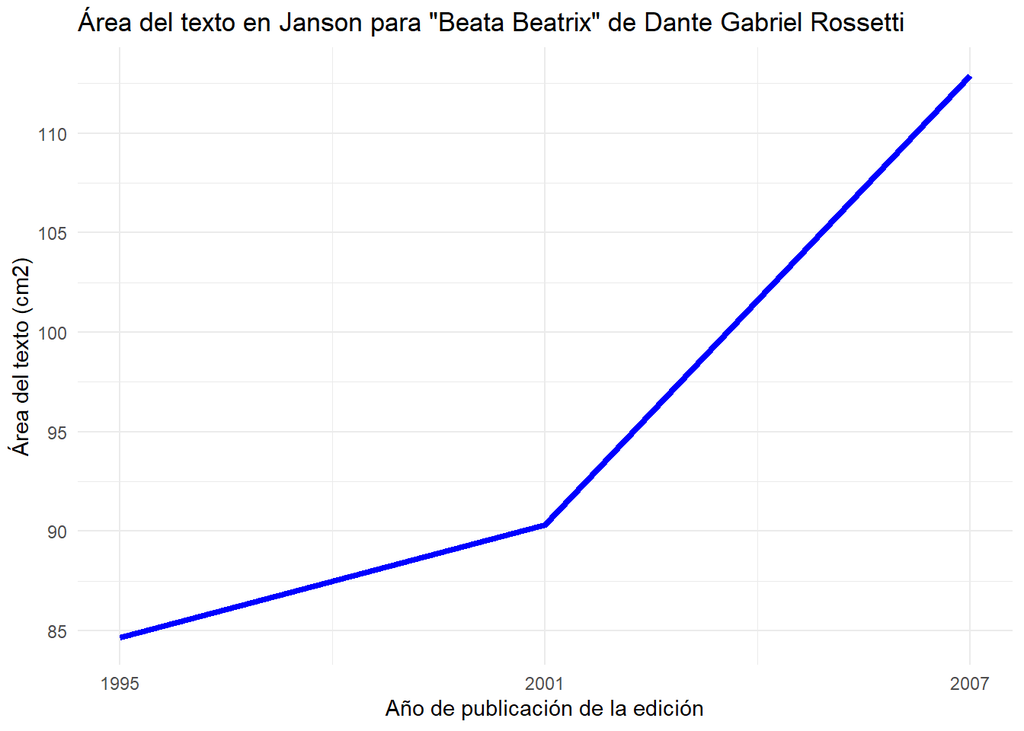

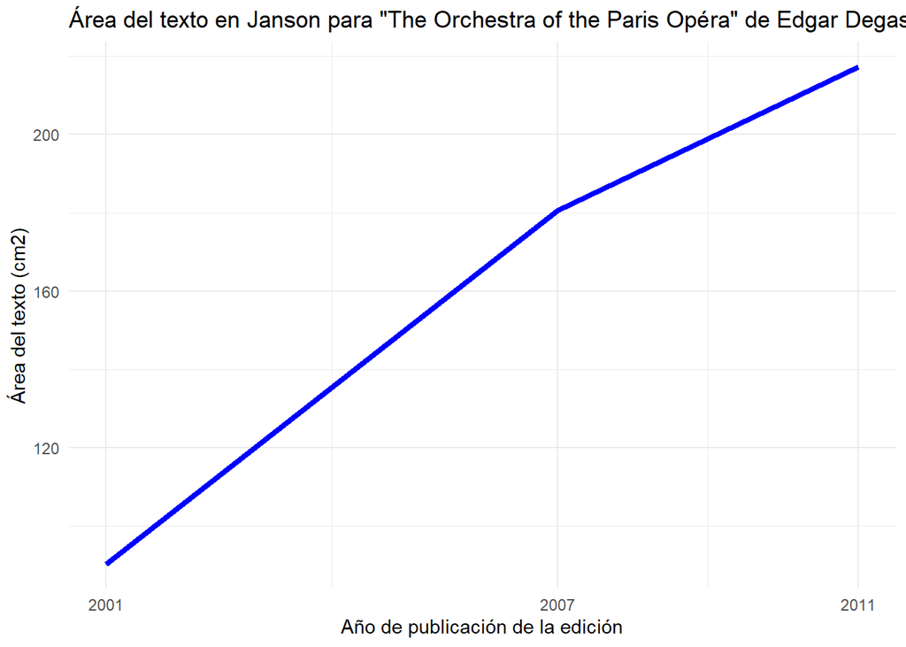

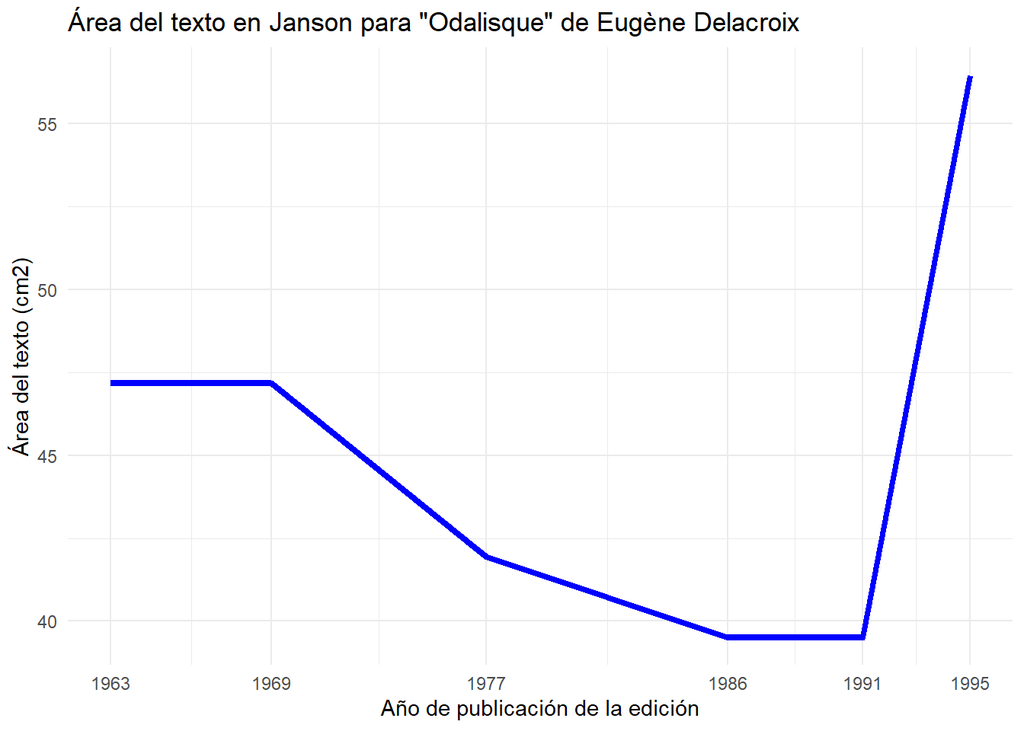

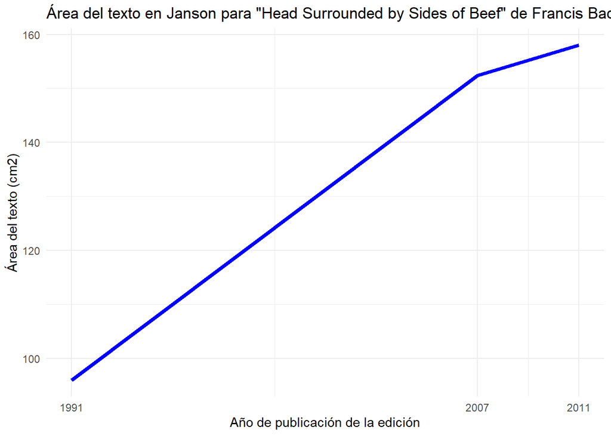

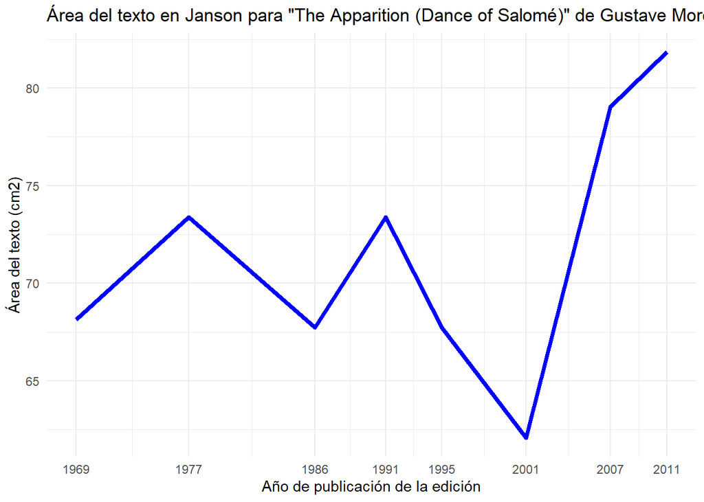

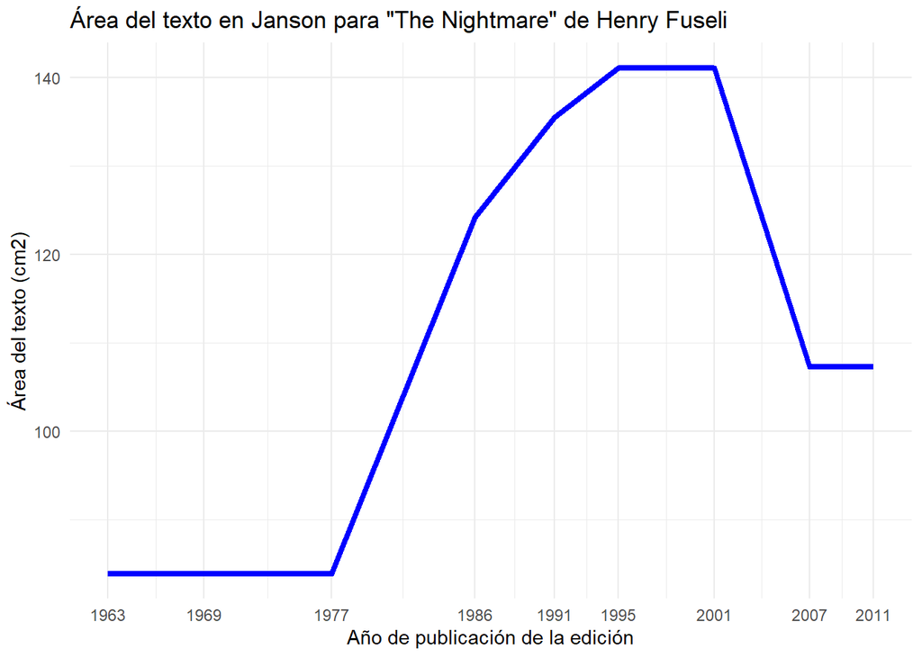

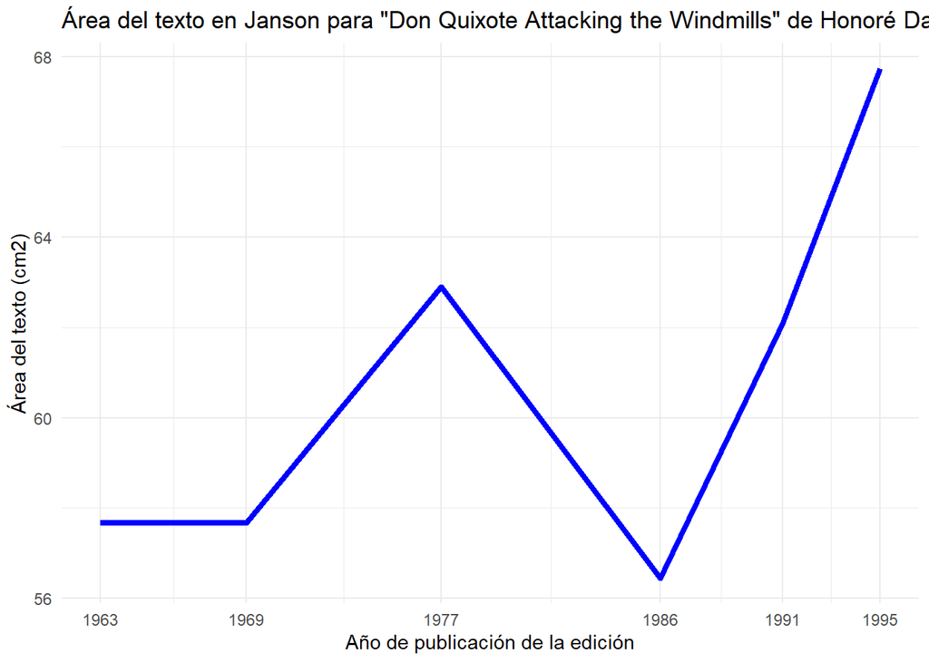

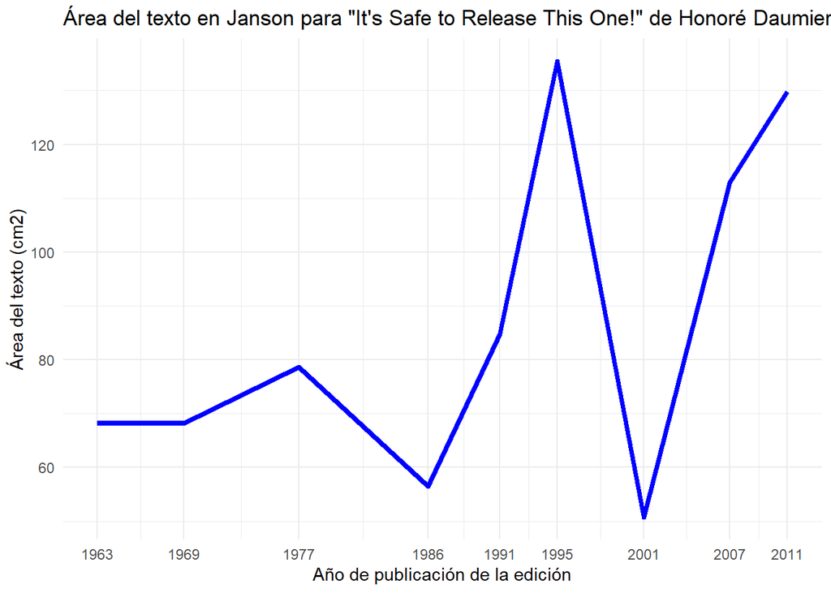

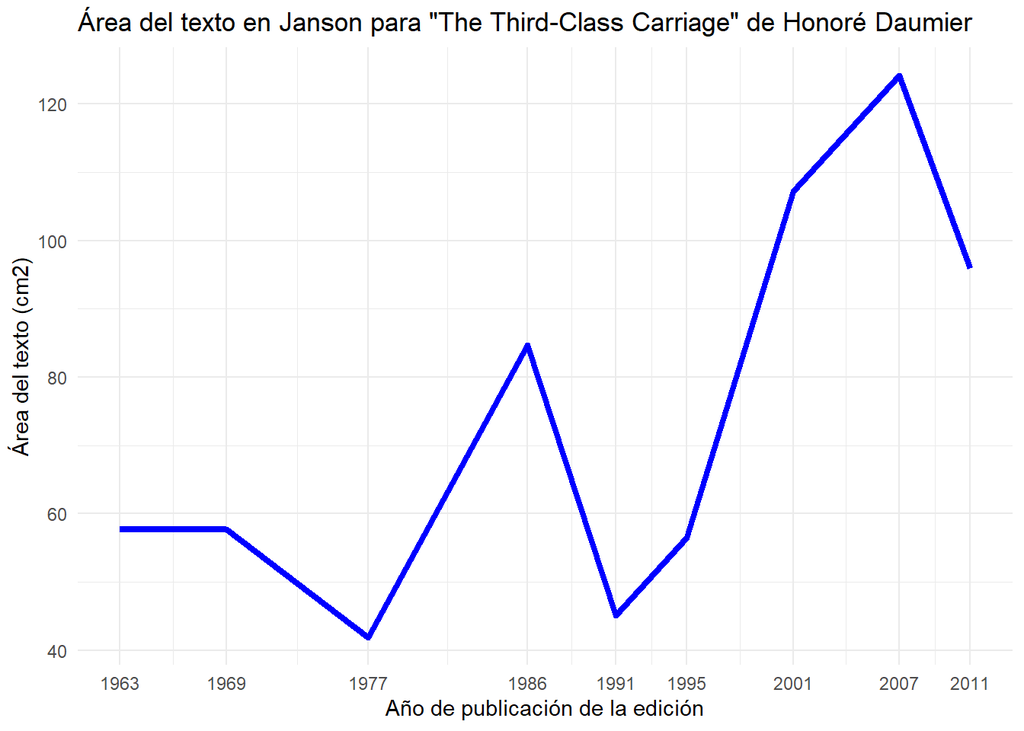

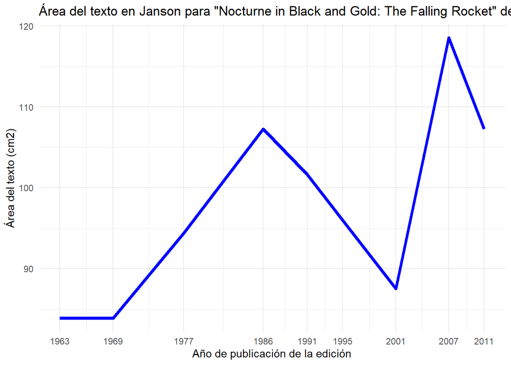

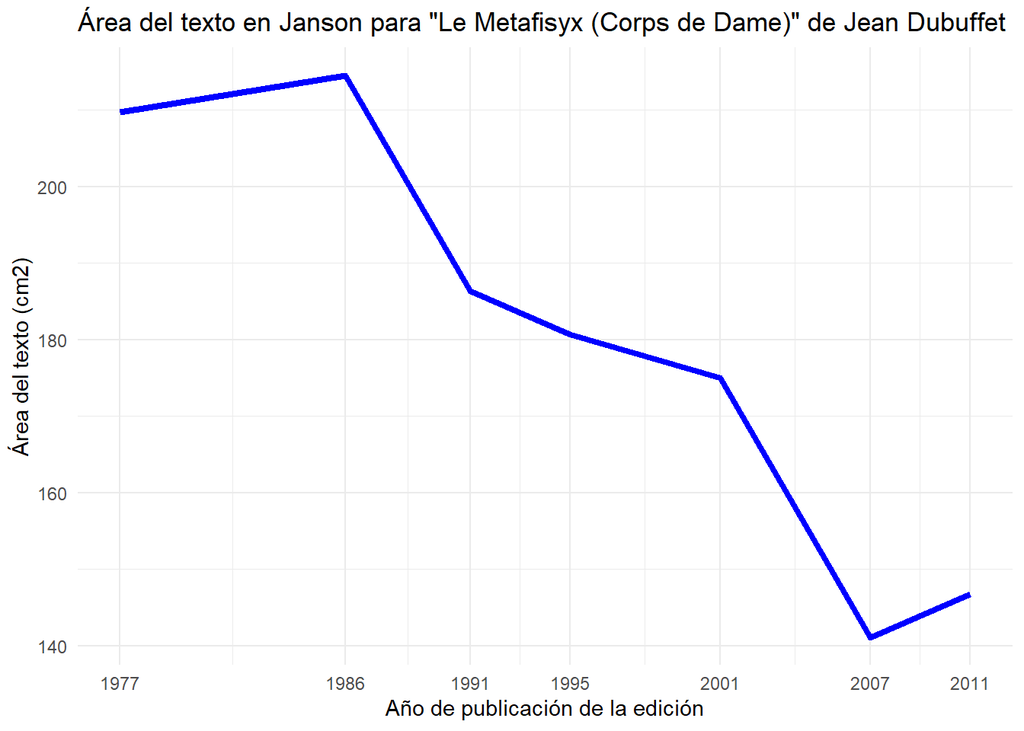

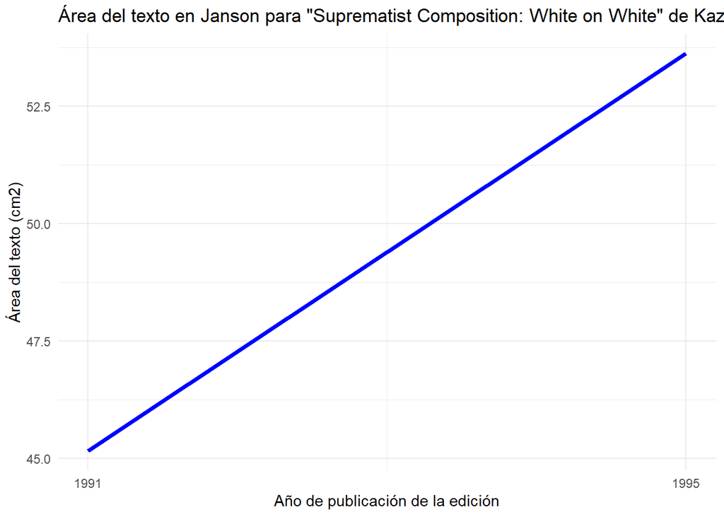

[3 more figures not shown]

```r
# Create a list of plots
plots_list2 <- map(trajectories, ~ {
  .x <- mutate(.x, start_date = as.integer(start_date), end_date = as.integer(end_date))
  title_of_work <- .x$title_of_work[1]
  artist_name <- .x$artist_name[1]

  ggplot(.x, aes(x = publication_year)) +
    geom_line(aes(y = area_of_text), color = "blue", size = 1.5) +  # Add blue thick line for area_of_text
    labs(
      title = paste("Área del texto en Janson para", shQuote(title_of_work), "de", artist_name),
      x = "Año de publicación de la edición",  # Change the x-axis label
      y = "Área del texto (cm2)",
    ) +
    scale_x_continuous(breaks = unique(.x$publication_year)) +  # Set unique publication years as breaks for x-axis
    theme_minimal()  # Optional: Customize the theme as needed
})
# Print the list of plots
walk(plots_list2, print)
```

Vemos que en general estas obras van adquiriendo mayor importancia en términos del espacio concedido en las sucesivas ediciones del Janson. Esa importancia puede reflejar un mayor volumen de investigación en torno a esas obras, volumen que puede que en parte involucre una puesta en cuestión de las dataciones y por ende un cambio en las mismas y/o en su status de *circa*.

Veamos el espacio de texto ocupado por las obras de los 13 artistas en el conjunto formado por los libros de Janson y de Gardner en sus sucesivas ediciones para compararlo con el promedio de todos los demás artistas:

```r
# Perform an inner join using SQL queries
query_space <- "
SELECT
  j.artist_name,
  SUM(j.area_of_text + g.area_of_text) AS total_area_of_text
FROM worksjanson AS j
INNER JOIN worksgardner AS g
ON j.artist_name = g.artist_name
GROUP BY j.artist_name
"

artists_space <- dbGetQuery(con, query_space)

dbWriteTable(con, "artists_space", artists_space)

mean(artists_space$total_area_of_text)
```

```
## [1] 37220.16
```

El promedio de area de texto para la totalidad de los artistas presentes en ambos libros es de 37220 cm<sup>2</sup>.

```r
query_space_circa <- "
SELECT a.*
FROM artists_space AS a
WHERE a.artist_name IN (SELECT DISTINCT artist_name FROM circa_changes)
"

artists_space_circa <- dbGetQuery(con, query_space_circa)

dbWriteTable(con, "artists_space_circa", artists_space_circa)

mean(artists_space_circa$total_area_of_text)
```

```
## [1] 89292.09
```

El promedio para el subconjunto de artistas cuyas obras cambiaron de estado de *circa* es de más del doble, 89292 cm<sup>2</sup>. Se excluye a Tadeo Zuccari porque no está presente en el libro de Gardner.

De acuerdo a este resultado, los artistas a cuyas obras se le atribuyen cambios de estado de *circa* tienen un mucho mayor espacio en los libros de Jansen y Gardner que el promedio total de artistas. Este protagonismo en los textos de Jansen y Gardner lo hemos tomado como un *proxy* del interés de la Historia del Arte en estos artistas, que a su vez puede tener como efecto la investigación específica sobre sus obras y una puesta en cuestión de la datación de algunas de ellas.

El dataset da para mucho más, pero es necesario concluir:

```r
# Close the database connection
dbDisconnect(con)
```